# Risk Factor Analysis

## Outcome Variable

**Outcome Variable:** stunted

## Predictor Variables

**Intervention Variable:** predexfd6

**Adjustment Set:**

- arm
- sex
- W_mage
- meducyrs
- feducyrs
- hhwealth_quart
- hfoodsec
- W_mhtcm
- vagbrth
- W_gagebrth
- W_birthwt
- W_birthlen
- W_nrooms
- W_nchldlt5
- month
- brthmon
- W_parity
- impfloor
- impsan
- safeh20
- delta_W_mage
- delta_meducyrs
- delta_feducyrs
- delta_hhwealth_quart
- delta_hfoodsec
- delta_W_mhtcm
- delta_vagbrth
- delta_W_gagebrth
- delta_W_birthwt
- delta_W_birthlen
- delta_W_nrooms
- delta_W_nchldlt5
- delta_month
- delta_brthmon
- delta_W_parity
- delta_impfloor
- delta_impsan
- delta_safeh20

## Stratifying Variables

The analysis was stratified on these variable(s):

- agecat
- studyid
- country

## Data Summary

| agecat | studyid | country | predexfd6 | stunted | n_cell | n |
| --- | --- | --- | --- | --- | --- | --- |
| Birth | ki0047075b-MAL-ED | BANGLADESH | 0 | 0 | 91 | 231 |
| Birth | ki0047075b-MAL-ED | BANGLADESH | 0 | 1 | 21 | 231 |
| Birth | ki0047075b-MAL-ED | BANGLADESH | 1 | 0 | 101 | 231 |
| Birth | ki0047075b-MAL-ED | BANGLADESH | 1 | 1 | 18 | 231 |
| Birth | ki0047075b-MAL-ED | BRAZIL | 0 | 0 | 134 | 175 |
| Birth | ki0047075b-MAL-ED | BRAZIL | 0 | 1 | 14 | 175 |
| Birth | ki0047075b-MAL-ED | BRAZIL | 1 | 0 | 24 | 175 |
| Birth | ki0047075b-MAL-ED | BRAZIL | 1 | 1 | 3 | 175 |
| Birth | ki0047075b-MAL-ED | INDIA | 0 | 0 | 149 | 190 |
| Birth | ki0047075b-MAL-ED | INDIA | 0 | 1 | 26 | 190 |
| Birth | ki0047075b-MAL-ED | INDIA | 1 | 0 | 10 | 190 |
| Birth | ki0047075b-MAL-ED | INDIA | 1 | 1 | 5 | 190 |
| Birth | ki0047075b-MAL-ED | NEPAL | 0 | 0 | 131 | 170 |
| Birth | ki0047075b-MAL-ED | NEPAL | 0 | 1 | 16 | 170 |
| Birth | ki0047075b-MAL-ED | NEPAL | 1 | 0 | 21 | 170 |
| Birth | ki0047075b-MAL-ED | NEPAL | 1 | 1 | 2 | 170 |
| Birth | ki0047075b-MAL-ED | PERU | 0 | 0 | 132 | 256 |
| Birth | ki0047075b-MAL-ED | PERU | 0 | 1 | 18 | 256 |
| Birth | ki0047075b-MAL-ED | PERU | 1 | 0 | 95 | 256 |
| Birth | ki0047075b-MAL-ED | PERU | 1 | 1 | 11 | 256 |
| Birth | ki0047075b-MAL-ED | SOUTH AFRICA | 0 | 0 | 188 | 211 |
| Birth | ki0047075b-MAL-ED | SOUTH AFRICA | 0 | 1 | 20 | 211 |
| Birth | ki0047075b-MAL-ED | SOUTH AFRICA | 1 | 0 | 1 | 211 |
| Birth | ki0047075b-MAL-ED | SOUTH AFRICA | 1 | 1 | 2 | 211 |
| Birth | ki0047075b-MAL-ED | TANZANIA, UNITED REPUBLIC OF | 0 | 0 | 102 | 119 |
| Birth | ki0047075b-MAL-ED | TANZANIA, UNITED REPUBLIC OF | 0 | 1 | 16 | 119 |
| Birth | ki0047075b-MAL-ED | TANZANIA, UNITED REPUBLIC OF | 1 | 0 | 1 | 119 |
| Birth | ki0047075b-MAL-ED | TANZANIA, UNITED REPUBLIC OF | 1 | 1 | 0 | 119 |
| Birth | ki1000108-CMC-V-BCS-2002 | INDIA | 0 | 0 | 0 | 7 |
| Birth | ki1000108-CMC-V-BCS-2002 | INDIA | 0 | 1 | 0 | 7 |

[output cut: 158 more lines]

The following strata were considered:

- agecat: 24 months, studyid: ki0047075b-MAL-ED, country: BANGLADESH
- agecat: 24 months, studyid: ki0047075b-MAL-ED, country: BRAZIL
- agecat: 24 months, studyid: ki0047075b-MAL-ED, country: INDIA
- agecat: 24 months, studyid: ki0047075b-MAL-ED, country: NEPAL
- agecat: 24 months, studyid: ki0047075b-MAL-ED, country: PERU
- agecat: 24 months, studyid: ki0047075b-MAL-ED, country: SOUTH AFRICA
- agecat: 24 months, studyid: ki0047075b-MAL-ED, country: TANZANIA, UNITED REPUBLIC OF
- agecat: 24 months, studyid: ki1000108-CMC-V-BCS-2002, country: INDIA
- agecat: 24 months, studyid: ki1000108-IRC, country: INDIA
- agecat: 24 months, studyid: ki1017093b-PROVIDE, country: BANGLADESH
- agecat: 24 months, studyid: ki1101329-Keneba, country: GAMBIA
- agecat: 24 months, studyid: ki1113344-GMS-Nepal, country: NEPAL
- agecat: 24 months, studyid: ki1148112-LCNI-5, country: MALAWI
- agecat: 24 months, studyid: kiGH5241-JiVitA-3, country: BANGLADESH
- agecat: 24 months, studyid: kiGH5241-JiVitA-4, country: BANGLADESH
- agecat: 6 months, studyid: ki0047075b-MAL-ED, country: BANGLADESH
- agecat: 6 months, studyid: ki0047075b-MAL-ED, country: BRAZIL
- agecat: 6 months, studyid: ki0047075b-MAL-ED, country: INDIA
- agecat: 6 months, studyid: ki0047075b-MAL-ED, country: NEPAL
- agecat: 6 months, studyid: ki0047075b-MAL-ED, country: PERU
- agecat: 6 months, studyid: ki0047075b-MAL-ED, country: SOUTH AFRICA
- agecat: 6 months, studyid: ki0047075b-MAL-ED, country: TANZANIA, UNITED REPUBLIC OF
- agecat: 6 months, studyid: ki1000108-CMC-V-BCS-2002, country: INDIA
- agecat: 6 months, studyid: ki1000108-IRC, country: INDIA
- agecat: 6 months, studyid: ki1000109-EE, country: PAKISTAN
- agecat: 6 months, studyid: ki1000304b-SAS-CompFeed, country: INDIA
- agecat: 6 months, studyid: ki1000304b-SAS-FoodSuppl, country: INDIA
- agecat: 6 months, studyid: ki1017093b-PROVIDE, country: BANGLADESH
- agecat: 6 months, studyid: ki1101329-Keneba, country: GAMBIA
- agecat: 6 months, studyid: ki1113344-GMS-Nepal, country: NEPAL
- agecat: 6 months, studyid: ki1148112-LCNI-5, country: MALAWI
- agecat: 6 months, studyid: kiGH5241-JiVitA-3, country: BANGLADESH
- agecat: 6 months, studyid: kiGH5241-JiVitA-4, country: BANGLADESH
- agecat: Birth, studyid: ki0047075b-MAL-ED, country: BANGLADESH
- agecat: Birth, studyid: ki0047075b-MAL-ED, country: BRAZIL
- agecat: Birth, studyid: ki0047075b-MAL-ED, country: INDIA
- agecat: Birth, studyid: ki0047075b-MAL-ED, country: NEPAL
- agecat: Birth, studyid: ki0047075b-MAL-ED, country: PERU
- agecat: Birth, studyid: ki0047075b-MAL-ED, country: SOUTH AFRICA
- agecat: Birth, studyid: ki0047075b-MAL-ED, country: TANZANIA, UNITED REPUBLIC OF
- agecat: Birth, studyid: ki1000108-CMC-V-BCS-2002, country: INDIA
- agecat: Birth, studyid: ki1000108-IRC, country: INDIA
- agecat: Birth, studyid: ki1000109-EE, country: PAKISTAN
- agecat: Birth, studyid: ki1000304b-SAS-CompFeed, country: INDIA
- agecat: Birth, studyid: ki1101329-Keneba, country: GAMBIA
- agecat: Birth, studyid: kiGH5241-JiVitA-3, country: BANGLADESH
- agecat: Birth, studyid: kiGH5241-JiVitA-4, country: BANGLADESH

### Dropped Strata

Some strata were dropped due to rare outcomes:

- agecat: Birth, studyid: ki0047075b-MAL-ED, country: BRAZIL
- agecat: Birth, studyid: ki0047075b-MAL-ED, country: NEPAL
- agecat: Birth, studyid: ki0047075b-MAL-ED, country: SOUTH AFRICA
- agecat: Birth, studyid: ki0047075b-MAL-ED, country: TANZANIA, UNITED REPUBLIC OF
- agecat: Birth, studyid: ki1000108-CMC-V-BCS-2002, country: INDIA
- agecat: Birth, studyid: ki1000108-IRC, country: INDIA
- agecat: Birth, studyid: ki1000109-EE, country: PAKISTAN
- agecat: Birth, studyid: ki1000304b-SAS-CompFeed, country: INDIA
- agecat: 6 months, studyid: ki0047075b-MAL-ED, country: BRAZIL
- agecat: 6 months, studyid: ki0047075b-MAL-ED, country: NEPAL
- agecat: 6 months, studyid: ki0047075b-MAL-ED, country: SOUTH AFRICA
- agecat: 6 months, studyid: ki0047075b-MAL-ED, country: TANZANIA, UNITED REPUBLIC OF
- agecat: 6 months, studyid: ki1000108-CMC-V-BCS-2002, country: INDIA
- agecat: 6 months, studyid: ki1000108-IRC, country: INDIA
- agecat: 6 months, studyid: ki1000304b-SAS-FoodSuppl, country: INDIA
- agecat: 24 months, studyid: ki0047075b-MAL-ED, country: BRAZIL
- agecat: 24 months, studyid: ki0047075b-MAL-ED, country: SOUTH AFRICA
- agecat: 24 months, studyid: ki0047075b-MAL-ED, country: TANZANIA, UNITED REPUBLIC OF
- agecat: 24 months, studyid: ki1000108-CMC-V-BCS-2002, country: INDIA
- agecat: 24 months, studyid: ki1000108-IRC, country: INDIA

## Methods Detail

We’re interested in the causal parameters $E[Y_a]$ for all values of $a \in \mathcal{A}$. These parameters represent the mean outcome if, possibly contrary to fact, we intervened to set all units to have $A=a$. Under the randomization and positivity assumptions, these are identified by the statistical parameters $\psi_a=E_W[E_{Y|A,W}(Y|A=a,W)]$. In addition, we’re interested in the mean of $Y$, $E[Y]$ under no intervention (the observed mean). We will estimate these parameters by using SuperLearner to fit the relevant likelihood factors – $E_{Y|A,W}(Y|A=a,W)$ and $p(A=a|W)$, and then updating our likelihood fit using a joint TMLE.

For unadjusted analyses ($W=\{\}$), initial likelihoods were estimated using Lrnr_glm to estimate the simple $E(Y|A)$ and Lrnr_mean to estimate $p(A)$. For adjusted analyses, a small library containing Lrnr_glmnet, Lrnr_xgboost, and Lrnr_mean was used.

Having estimated these parameters, we will then use the delta method to estimate relative risks and attributable risks relative to a prespecified baseline level of $A$.

# Results Detail

## Results Plots

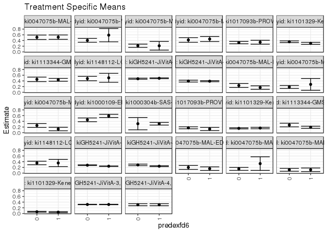

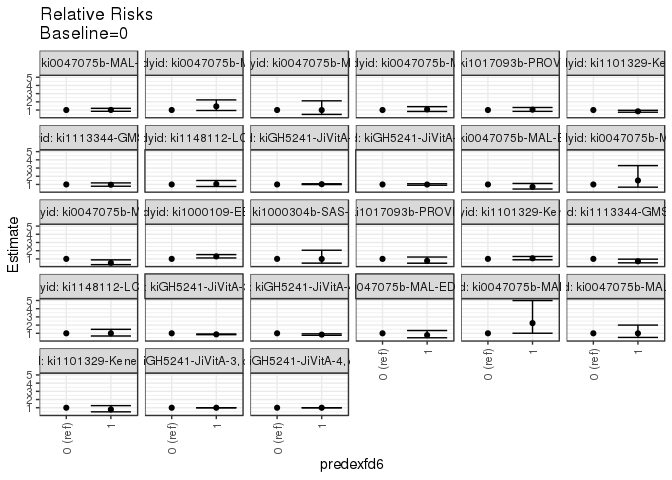

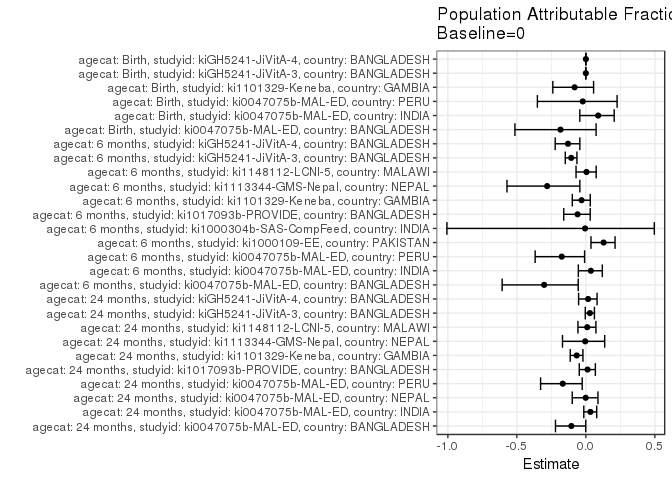

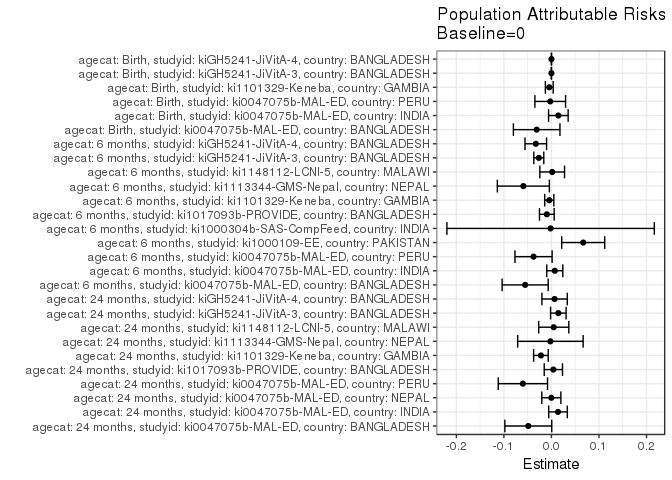

## Results Table

### Parameter: TSM

| agecat | studyid | country | intervention_level | baseline_level | estimate | ci_lower | ci_upper |
| --- | --- | --- | --- | --- | --- | --- | --- |
| Birth | ki0047075b-MAL-ED | BANGLADESH | 0 | NA | 0.1998768 | 0.1286192 | 0.2711345 |
| Birth | ki0047075b-MAL-ED | BANGLADESH | 1 | NA | 0.1561550 | 0.0926366 | 0.2196734 |
| Birth | ki0047075b-MAL-ED | INDIA | 0 | NA | 0.1485714 | 0.0957370 | 0.2014058 |
| Birth | ki0047075b-MAL-ED | INDIA | 1 | NA | 0.3333333 | 0.0941438 | 0.5725228 |
| Birth | ki0047075b-MAL-ED | PERU | 0 | NA | 0.1158110 | 0.0653656 | 0.1662564 |
| Birth | ki0047075b-MAL-ED | PERU | 1 | NA | 0.1151427 | 0.0520344 | 0.1782511 |
| Birth | ki1101329-Keneba | GAMBIA | 0 | NA | 0.0602159 | 0.0451888 | 0.0752430 |
| Birth | ki1101329-Keneba | GAMBIA | 1 | NA | 0.0477448 | 0.0288474 | 0.0666423 |
| Birth | kiGH5241-JiVitA-3 | BANGLADESH | 0 | NA | 0.3166329 | 0.3090240 | 0.3242418 |
| Birth | kiGH5241-JiVitA-3 | BANGLADESH | 1 | NA | 0.3166222 | 0.3090127 | 0.3242317 |
| Birth | kiGH5241-JiVitA-4 | BANGLADESH | 0 | NA | 0.3089058 | 0.2721476 | 0.3456640 |
| Birth | kiGH5241-JiVitA-4 | BANGLADESH | 1 | NA | 0.3089609 | 0.2722043 | 0.3457174 |
| 6 months | ki0047075b-MAL-ED | BANGLADESH | 0 | NA | 0.2382412 | 0.1674035 | 0.3090789 |
| 6 months | ki0047075b-MAL-ED | BANGLADESH | 1 | NA | 0.1675634 | 0.1067862 | 0.2283406 |
| 6 months | ki0047075b-MAL-ED | INDIA | 0 | NA | 0.1869159 | 0.1345715 | 0.2392603 |
| 6 months | ki0047075b-MAL-ED | INDIA | 1 | NA | 0.2777778 | 0.0704135 | 0.4851421 |
| 6 months | ki0047075b-MAL-ED | PERU | 0 | NA | 0.2532603 | 0.1851612 | 0.3213594 |
| 6 months | ki0047075b-MAL-ED | PERU | 1 | NA | 0.1285444 | 0.0668694 | 0.1902194 |
| 6 months | ki1000109-EE | PAKISTAN | 0 | NA | 0.4519707 | 0.3866482 | 0.5172932 |
| 6 months | ki1000109-EE | PAKISTAN | 1 | NA | 0.5879768 | 0.5298832 | 0.6460705 |
| 6 months | ki1000304b-SAS-CompFeed | INDIA | 0 | NA | 0.3157895 | 0.1014523 | 0.5301266 |
| 6 months | ki1000304b-SAS-CompFeed | INDIA | 1 | NA | 0.3139842 | 0.2679102 | 0.3600581 |
| 6 months | ki1017093b-PROVIDE | BANGLADESH | 0 | NA | 0.1709084 | 0.1362609 | 0.2055559 |
| 6 months | ki1017093b-PROVIDE | BANGLADESH | 1 | NA | 0.1302430 | 0.0740737 | 0.1864124 |
| 6 months | ki1101329-Keneba | GAMBIA | 0 | NA | 0.1523893 | 0.1338795 | 0.1708990 |
| 6 months | ki1101329-Keneba | GAMBIA | 1 | NA | 0.1632215 | 0.1382162 | 0.1882268 |
| 6 months | ki1113344-GMS-Nepal | NEPAL | 0 | NA | 0.2697094 | 0.2041516 | 0.3352672 |
| 6 months | ki1113344-GMS-Nepal | NEPAL | 1 | NA | 0.1902979 | 0.1525994 | 0.2279964 |
| 6 months | ki1148112-LCNI-5 | MALAWI | 0 | NA | 0.3549988 | 0.2926049 | 0.4173927 |
| 6 months | ki1148112-LCNI-5 | MALAWI | 1 | NA | 0.3542241 | 0.2279951 | 0.4804531 |
| 6 months | kiGH5241-JiVitA-3 | BANGLADESH | 0 | NA | 0.2773939 | 0.2645856 | 0.2902021 |
| 6 months | kiGH5241-JiVitA-3 | BANGLADESH | 1 | NA | 0.2419059 | 0.2332766 | 0.2505352 |
| 6 months | kiGH5241-JiVitA-4 | BANGLADESH | 0 | NA | 0.2874342 | 0.2597950 | 0.3150735 |
| 6 months | kiGH5241-JiVitA-4 | BANGLADESH | 1 | NA | 0.2420520 | 0.2263620 | 0.2577421 |
| 24 months | ki0047075b-MAL-ED | BANGLADESH | 0 | NA | 0.5127955 | 0.4347977 | 0.5907932 |
| 24 months | ki0047075b-MAL-ED | BANGLADESH | 1 | NA | 0.5171303 | 0.4401868 | 0.5940739 |
| 24 months | ki0047075b-MAL-ED | INDIA | 0 | NA | 0.4057971 | 0.3387537 | 0.4728406 |
| 24 months | ki0047075b-MAL-ED | INDIA | 1 | NA | 0.5882353 | 0.3537610 | 0.8227096 |
| 24 months | ki0047075b-MAL-ED | NEPAL | 0 | NA | 0.2160804 | 0.1587713 | 0.2733895 |
| 24 months | ki0047075b-MAL-ED | NEPAL | 1 | NA | 0.2142857 | 0.0619658 | 0.3666056 |
| 24 months | ki0047075b-MAL-ED | PERU | 0 | NA | 0.4186343 | 0.3374613 | 0.4998073 |
| 24 months | ki0047075b-MAL-ED | PERU | 1 | NA | 0.4513455 | 0.3633499 | 0.5393410 |
| 24 months | ki1017093b-PROVIDE | BANGLADESH | 0 | NA | 0.3252144 | 0.2829353 | 0.3674935 |
| 24 months | ki1017093b-PROVIDE | BANGLADESH | 1 | NA | 0.3396929 | 0.2710336 | 0.4083522 |
| 24 months | ki1101329-Keneba | GAMBIA | 0 | NA | 0.3565389 | 0.3279505 | 0.3851273 |
| 24 months | ki1101329-Keneba | GAMBIA | 1 | NA | 0.2998016 | 0.2640379 | 0.3355653 |
| 24 months | ki1113344-GMS-Nepal | NEPAL | 0 | NA | 0.4542421 | 0.3742204 | 0.5342638 |
| 24 months | ki1113344-GMS-Nepal | NEPAL | 1 | NA | 0.4377013 | 0.3872661 | 0.4881364 |
| 24 months | ki1148112-LCNI-5 | MALAWI | 0 | NA | 0.4818809 | 0.4043416 | 0.5594202 |
| 24 months | ki1148112-LCNI-5 | MALAWI | 1 | NA | 0.5086106 | 0.3519186 | 0.6653026 |
| 24 months | kiGH5241-JiVitA-3 | BANGLADESH | 0 | NA | 0.4762361 | 0.4560624 | 0.4964097 |
| 24 months | kiGH5241-JiVitA-3 | BANGLADESH | 1 | NA | 0.4916047 | 0.4776799 | 0.5055294 |
| 24 months | kiGH5241-JiVitA-4 | BANGLADESH | 0 | NA | 0.3924695 | 0.3597202 | 0.4252188 |
| 24 months | kiGH5241-JiVitA-4 | BANGLADESH | 1 | NA | 0.3887989 | 0.3695409 | 0.4080569 |

### Parameter: E(Y)

| agecat | studyid | country | intervention_level | baseline_level | estimate | ci_lower | ci_upper |
| --- | --- | --- | --- | --- | --- | --- | --- |
| Birth | ki0047075b-MAL-ED | BANGLADESH | NA | NA | 0.1688312 | 0.1204189 | 0.2172434 |
| Birth | ki0047075b-MAL-ED | INDIA | NA | NA | 0.1631579 | 0.1104782 | 0.2158376 |
| Birth | ki0047075b-MAL-ED | PERU | NA | NA | 0.1132813 | 0.0743812 | 0.1521813 |
| Birth | ki1101329-Keneba | GAMBIA | NA | NA | 0.0556745 | 0.0436637 | 0.0676854 |
| Birth | kiGH5241-JiVitA-3 | BANGLADESH | NA | NA | 0.3166335 | 0.3090239 | 0.3242430 |
| Birth | kiGH5241-JiVitA-4 | BANGLADESH | NA | NA | 0.3089961 | 0.2722361 | 0.3457561 |
| 6 months | ki0047075b-MAL-ED | BANGLADESH | NA | NA | 0.1829787 | 0.1334386 | 0.2325189 |
| 6 months | ki0047075b-MAL-ED | INDIA | NA | NA | 0.1939655 | 0.1429760 | 0.2449551 |
| 6 months | ki0047075b-MAL-ED | PERU | NA | NA | 0.2156134 | 0.1663773 | 0.2648495 |
| 6 months | ki1000109-EE | PAKISTAN | NA | NA | 0.5188172 | 0.4679751 | 0.5696593 |
| 6 months | ki1000304b-SAS-CompFeed | INDIA | NA | NA | 0.3140704 | 0.2712850 | 0.3568557 |
| 6 months | ki1017093b-PROVIDE | BANGLADESH | NA | NA | 0.1612350 | 0.1313580 | 0.1911120 |
| 6 months | ki1101329-Keneba | GAMBIA | NA | NA | 0.1477987 | 0.1318701 | 0.1637274 |
| 6 months | ki1113344-GMS-Nepal | NEPAL | NA | NA | 0.2106227 | 0.1763897 | 0.2448557 |
| 6 months | ki1148112-LCNI-5 | MALAWI | NA | NA | 0.3566176 | 0.2995882 | 0.4136471 |
| 6 months | kiGH5241-JiVitA-3 | BANGLADESH | NA | NA | 0.2508093 | 0.2426385 | 0.2589801 |
| 6 months | kiGH5241-JiVitA-4 | BANGLADESH | NA | NA | 0.2545198 | 0.2394884 | 0.2695513 |
| 24 months | ki0047075b-MAL-ED | BANGLADESH | NA | NA | 0.4641148 | 0.3963405 | 0.5318891 |
| 24 months | ki0047075b-MAL-ED | INDIA | NA | NA | 0.4196429 | 0.3548715 | 0.4844143 |
| 24 months | ki0047075b-MAL-ED | NEPAL | NA | NA | 0.2158590 | 0.1622206 | 0.2694975 |
| 24 months | ki0047075b-MAL-ED | PERU | NA | NA | 0.3585859 | 0.2916158 | 0.4255559 |
| 24 months | ki1017093b-PROVIDE | BANGLADESH | NA | NA | 0.3292894 | 0.2909105 | 0.3676684 |
| 24 months | ki1101329-Keneba | GAMBIA | NA | NA | 0.3344349 | 0.3106543 | 0.3582155 |
| 24 months | ki1113344-GMS-Nepal | NEPAL | NA | NA | 0.4520833 | 0.4075129 | 0.4966538 |
| 24 months | ki1148112-LCNI-5 | MALAWI | NA | NA | 0.4867725 | 0.4153250 | 0.5582200 |
| 24 months | kiGH5241-JiVitA-3 | BANGLADESH | NA | NA | 0.4907516 | 0.4775997 | 0.5039035 |
| 24 months | kiGH5241-JiVitA-4 | BANGLADESH | NA | NA | 0.3991375 | 0.3806098 | 0.4176653 |

### Parameter: RR

| agecat | studyid | country | intervention_level | baseline_level | estimate | ci_lower | ci_upper |
| --- | --- | --- | --- | --- | --- | --- | --- |
| Birth | ki0047075b-MAL-ED | BANGLADESH | 0 | 0 | 1.0000000 | 1.0000000 | 1.0000000 |
| Birth | ki0047075b-MAL-ED | BANGLADESH | 1 | 0 | 0.7812561 | 0.4561446 | 1.3380869 |
| Birth | ki0047075b-MAL-ED | INDIA | 0 | 0 | 1.0000000 | 1.0000000 | 1.0000000 |
| Birth | ki0047075b-MAL-ED | INDIA | 1 | 0 | 2.2435897 | 1.0072492 | 4.9974675 |
| Birth | ki0047075b-MAL-ED | PERU | 0 | 0 | 1.0000000 | 1.0000000 | 1.0000000 |
| Birth | ki0047075b-MAL-ED | PERU | 1 | 0 | 0.9942297 | 0.4946331 | 1.9984362 |
| Birth | ki1101329-Keneba | GAMBIA | 0 | 0 | 1.0000000 | 1.0000000 | 1.0000000 |
| Birth | ki1101329-Keneba | GAMBIA | 1 | 0 | 0.7928943 | 0.5004599 | 1.2562073 |
| Birth | kiGH5241-JiVitA-3 | BANGLADESH | 0 | 0 | 1.0000000 | 1.0000000 | 1.0000000 |
| Birth | kiGH5241-JiVitA-3 | BANGLADESH | 1 | 0 | 0.9999662 | 0.9999319 | 1.0000005 |
| Birth | kiGH5241-JiVitA-4 | BANGLADESH | 0 | 0 | 1.0000000 | 1.0000000 | 1.0000000 |
| Birth | kiGH5241-JiVitA-4 | BANGLADESH | 1 | 0 | 1.0001782 | 0.9994356 | 1.0009214 |
| 6 months | ki0047075b-MAL-ED | BANGLADESH | 0 | 0 | 1.0000000 | 1.0000000 | 1.0000000 |
| 6 months | ki0047075b-MAL-ED | BANGLADESH | 1 | 0 | 0.7033352 | 0.4421234 | 1.1188740 |
| 6 months | ki0047075b-MAL-ED | INDIA | 0 | 0 | 1.0000000 | 1.0000000 | 1.0000000 |
| 6 months | ki0047075b-MAL-ED | INDIA | 1 | 0 | 1.4861111 | 0.6695514 | 3.2985161 |
| 6 months | ki0047075b-MAL-ED | PERU | 0 | 0 | 1.0000000 | 1.0000000 | 1.0000000 |
| 6 months | ki0047075b-MAL-ED | PERU | 1 | 0 | 0.5075584 | 0.2932418 | 0.8785091 |
| 6 months | ki1000109-EE | PAKISTAN | 0 | 0 | 1.0000000 | 1.0000000 | 1.0000000 |
| 6 months | ki1000109-EE | PAKISTAN | 1 | 0 | 1.3009179 | 1.1123096 | 1.5215076 |
| 6 months | ki1000304b-SAS-CompFeed | INDIA | 0 | 0 | 1.0000000 | 1.0000000 | 1.0000000 |
| 6 months | ki1000304b-SAS-CompFeed | INDIA | 1 | 0 | 0.9942832 | 0.4810773 | 2.0549693 |
| 6 months | ki1017093b-PROVIDE | BANGLADESH | 0 | 0 | 1.0000000 | 1.0000000 | 1.0000000 |
| 6 months | ki1017093b-PROVIDE | BANGLADESH | 1 | 0 | 0.7620633 | 0.4742690 | 1.2244959 |
| 6 months | ki1101329-Keneba | GAMBIA | 0 | 0 | 1.0000000 | 1.0000000 | 1.0000000 |
| 6 months | ki1101329-Keneba | GAMBIA | 1 | 0 | 1.0710829 | 0.8883156 | 1.2914538 |
| 6 months | ki1113344-GMS-Nepal | NEPAL | 0 | 0 | 1.0000000 | 1.0000000 | 1.0000000 |
| 6 months | ki1113344-GMS-Nepal | NEPAL | 1 | 0 | 0.7055665 | 0.5158250 | 0.9651026 |
| 6 months | ki1148112-LCNI-5 | MALAWI | 0 | 0 | 1.0000000 | 1.0000000 | 1.0000000 |
| 6 months | ki1148112-LCNI-5 | MALAWI | 1 | 0 | 0.9978177 | 0.6709400 | 1.4839481 |
| 6 months | kiGH5241-JiVitA-3 | BANGLADESH | 0 | 0 | 1.0000000 | 1.0000000 | 1.0000000 |
| 6 months | kiGH5241-JiVitA-3 | BANGLADESH | 1 | 0 | 0.8720665 | 0.8291437 | 0.9172113 |
| 6 months | kiGH5241-JiVitA-4 | BANGLADESH | 0 | 0 | 1.0000000 | 1.0000000 | 1.0000000 |
| 6 months | kiGH5241-JiVitA-4 | BANGLADESH | 1 | 0 | 0.8421127 | 0.7564662 | 0.9374560 |
| 24 months | ki0047075b-MAL-ED | BANGLADESH | 0 | 0 | 1.0000000 | 1.0000000 | 1.0000000 |
| 24 months | ki0047075b-MAL-ED | BANGLADESH | 1 | 0 | 1.0084535 | 0.8440456 | 1.2048856 |
| 24 months | ki0047075b-MAL-ED | INDIA | 0 | 0 | 1.0000000 | 1.0000000 | 1.0000000 |
| 24 months | ki0047075b-MAL-ED | INDIA | 1 | 0 | 1.4495798 | 0.9415618 | 2.2316981 |
| 24 months | ki0047075b-MAL-ED | NEPAL | 0 | 0 | 1.0000000 | 1.0000000 | 1.0000000 |
| 24 months | ki0047075b-MAL-ED | NEPAL | 1 | 0 | 0.9916944 | 0.4643883 | 2.1177486 |
| 24 months | ki0047075b-MAL-ED | PERU | 0 | 0 | 1.0000000 | 1.0000000 | 1.0000000 |
| 24 months | ki0047075b-MAL-ED | PERU | 1 | 0 | 1.0781377 | 0.8245626 | 1.4096939 |
| 24 months | ki1017093b-PROVIDE | BANGLADESH | 0 | 0 | 1.0000000 | 1.0000000 | 1.0000000 |
| 24 months | ki1017093b-PROVIDE | BANGLADESH | 1 | 0 | 1.0445198 | 0.8342773 | 1.3077445 |
| 24 months | ki1101329-Keneba | GAMBIA | 0 | 0 | 1.0000000 | 1.0000000 | 1.0000000 |
| 24 months | ki1101329-Keneba | GAMBIA | 1 | 0 | 0.8408664 | 0.7322375 | 0.9656107 |
| 24 months | ki1113344-GMS-Nepal | NEPAL | 0 | 0 | 1.0000000 | 1.0000000 | 1.0000000 |
| 24 months | ki1113344-GMS-Nepal | NEPAL | 1 | 0 | 0.9635859 | 0.7820907 | 1.1871998 |
| 24 months | ki1148112-LCNI-5 | MALAWI | 0 | 0 | 1.0000000 | 1.0000000 | 1.0000000 |
| 24 months | ki1148112-LCNI-5 | MALAWI | 1 | 0 | 1.0554695 | 0.7510502 | 1.4832775 |
| 24 months | kiGH5241-JiVitA-3 | BANGLADESH | 0 | 0 | 1.0000000 | 1.0000000 | 1.0000000 |
| 24 months | kiGH5241-JiVitA-3 | BANGLADESH | 1 | 0 | 1.0322710 | 0.9877431 | 1.0788061 |
| 24 months | kiGH5241-JiVitA-4 | BANGLADESH | 0 | 0 | 1.0000000 | 1.0000000 | 1.0000000 |
| 24 months | kiGH5241-JiVitA-4 | BANGLADESH | 1 | 0 | 0.9906473 | 0.9068782 | 1.0821542 |

### Parameter: PAR

| agecat | studyid | country | intervention_level | baseline_level | estimate | ci_lower | ci_upper |
| --- | --- | --- | --- | --- | --- | --- | --- |
| Birth | ki0047075b-MAL-ED | BANGLADESH | 0 | NA | -0.0310457 | -0.0800307 | 0.0179393 |
| Birth | ki0047075b-MAL-ED | INDIA | 0 | NA | 0.0145865 | -0.0060153 | 0.0351882 |
| Birth | ki0047075b-MAL-ED | PERU | 0 | NA | -0.0025297 | -0.0348113 | 0.0297518 |
| Birth | ki1101329-Keneba | GAMBIA | 0 | NA | -0.0045414 | -0.0127508 | 0.0036681 |
| Birth | kiGH5241-JiVitA-3 | BANGLADESH | 0 | NA | 0.0000006 | -0.0000077 | 0.0000089 |
| Birth | kiGH5241-JiVitA-4 | BANGLADESH | 0 | NA | 0.0000903 | -0.0000918 | 0.0002723 |
| 6 months | ki0047075b-MAL-ED | BANGLADESH | 0 | NA | -0.0552625 | -0.1037204 | -0.0068045 |
| 6 months | ki0047075b-MAL-ED | INDIA | 0 | NA | 0.0070496 | -0.0098371 | 0.0239364 |
| 6 months | ki0047075b-MAL-ED | PERU | 0 | NA | -0.0376469 | -0.0767187 | 0.0014249 |
| 6 months | ki1000109-EE | PAKISTAN | 0 | NA | 0.0668465 | 0.0215978 | 0.1120952 |
| 6 months | ki1000304b-SAS-CompFeed | INDIA | 0 | NA | -0.0017191 | -0.2199177 | 0.2164795 |
| 6 months | ki1017093b-PROVIDE | BANGLADESH | 0 | NA | -0.0096734 | -0.0251396 | 0.0057928 |
| 6 months | ki1101329-Keneba | GAMBIA | 0 | NA | -0.0045905 | -0.0141883 | 0.0050073 |
| 6 months | ki1113344-GMS-Nepal | NEPAL | 0 | NA | -0.0590867 | -0.1138137 | -0.0043597 |
| 6 months | ki1148112-LCNI-5 | MALAWI | 0 | NA | 0.0016189 | -0.0243640 | 0.0276017 |
| 6 months | kiGH5241-JiVitA-3 | BANGLADESH | 0 | NA | -0.0265846 | -0.0370715 | -0.0160977 |
| 6 months | kiGH5241-JiVitA-4 | BANGLADESH | 0 | NA | -0.0329144 | -0.0556184 | -0.0102104 |
| 24 months | ki0047075b-MAL-ED | BANGLADESH | 0 | NA | -0.0486806 | -0.0980095 | 0.0006483 |
| 24 months | ki0047075b-MAL-ED | INDIA | 0 | NA | 0.0138458 | -0.0057185 | 0.0334100 |
| 24 months | ki0047075b-MAL-ED | NEPAL | 0 | NA | -0.0002214 | -0.0202957 | 0.0198530 |
| 24 months | ki0047075b-MAL-ED | PERU | 0 | NA | -0.0600485 | -0.1118523 | -0.0082446 |
| 24 months | ki1017093b-PROVIDE | BANGLADESH | 0 | NA | 0.0040750 | -0.0151246 | 0.0232746 |
| 24 months | ki1101329-Keneba | GAMBIA | 0 | NA | -0.0221040 | -0.0374692 | -0.0067388 |
| 24 months | ki1113344-GMS-Nepal | NEPAL | 0 | NA | -0.0021587 | -0.0710207 | 0.0667032 |
| 24 months | ki1148112-LCNI-5 | MALAWI | 0 | NA | 0.0048916 | -0.0267746 | 0.0365577 |
| 24 months | kiGH5241-JiVitA-3 | BANGLADESH | 0 | NA | 0.0145155 | -0.0017950 | 0.0308260 |
| 24 months | kiGH5241-JiVitA-4 | BANGLADESH | 0 | NA | 0.0066680 | -0.0200356 | 0.0333716 |

### Parameter: PAF

| agecat | studyid | country | intervention_level | baseline_level | estimate | ci_lower | ci_upper |
| --- | --- | --- | --- | --- | --- | --- | --- |
| Birth | ki0047075b-MAL-ED | BANGLADESH | 0 | NA | -0.1838858 | -0.5140429 | 0.0742762 |
| Birth | ki0047075b-MAL-ED | INDIA | 0 | NA | 0.0894009 | -0.0435793 | 0.2054358 |
| Birth | ki0047075b-MAL-ED | PERU | 0 | NA | -0.0223316 | -0.3511580 | 0.2264695 |
| Birth | ki1101329-Keneba | GAMBIA | 0 | NA | -0.0815700 | -0.2393042 | 0.0560883 |
| Birth | kiGH5241-JiVitA-3 | BANGLADESH | 0 | NA | 0.0000018 | -0.0000244 | 0.0000280 |
| Birth | kiGH5241-JiVitA-4 | BANGLADESH | 0 | NA | 0.0002922 | -0.0002977 | 0.0008817 |
| 6 months | ki0047075b-MAL-ED | BANGLADESH | 0 | NA | -0.3020158 | -0.6065282 | -0.0552228 |
| 6 months | ki0047075b-MAL-ED | INDIA | 0 | NA | 0.0363448 | -0.0544615 | 0.1193312 |
| 6 months | ki0047075b-MAL-ED | PERU | 0 | NA | -0.1746038 | -0.3673359 | -0.0090381 |
| 6 months | ki1000109-EE | PAKISTAN | 0 | NA | 0.1288440 | 0.0372116 | 0.2117553 |
| 6 months | ki1000304b-SAS-CompFeed | INDIA | 0 | NA | -0.0054737 | -1.0068383 | 0.4962338 |
| 6 months | ki1017093b-PROVIDE | BANGLADESH | 0 | NA | -0.0599958 | -0.1601948 | 0.0315495 |
| 6 months | ki1101329-Keneba | GAMBIA | 0 | NA | -0.0310592 | -0.0982155 | 0.0319904 |
| 6 months | ki1113344-GMS-Nepal | NEPAL | 0 | NA | -0.2805334 | -0.5715451 | -0.0434099 |
| 6 months | ki1148112-LCNI-5 | MALAWI | 0 | NA | 0.0045395 | -0.0710470 | 0.0747916 |
| 6 months | kiGH5241-JiVitA-3 | BANGLADESH | 0 | NA | -0.1059954 | -0.1490197 | -0.0645821 |
| 6 months | kiGH5241-JiVitA-4 | BANGLADESH | 0 | NA | -0.1293196 | -0.2222218 | -0.0434790 |
| 24 months | ki0047075b-MAL-ED | BANGLADESH | 0 | NA | -0.1048892 | -0.2200004 | -0.0006391 |
| 24 months | ki0047075b-MAL-ED | INDIA | 0 | NA | 0.0329941 | -0.0148853 | 0.0786148 |
| 24 months | ki0047075b-MAL-ED | NEPAL | 0 | NA | -0.0010255 | -0.0984795 | 0.0877826 |
| 24 months | ki0047075b-MAL-ED | PERU | 0 | NA | -0.1674591 | -0.3279142 | -0.0263922 |
| 24 months | ki1017093b-PROVIDE | BANGLADESH | 0 | NA | 0.0123751 | -0.0476494 | 0.0689606 |
| 24 months | ki1101329-Keneba | GAMBIA | 0 | NA | -0.0660936 | -0.1131871 | -0.0209924 |
| 24 months | ki1113344-GMS-Nepal | NEPAL | 0 | NA | -0.0047751 | -0.1692783 | 0.1365845 |
| 24 months | ki1148112-LCNI-5 | MALAWI | 0 | NA | 0.0100490 | -0.0571740 | 0.0729975 |
| 24 months | kiGH5241-JiVitA-3 | BANGLADESH | 0 | NA | 0.0295781 | -0.0041818 | 0.0622030 |
| 24 months | kiGH5241-JiVitA-4 | BANGLADESH | 0 | NA | 0.0167060 | -0.0525442 | 0.0814000 |